# Sparrow Output Summary

Heather Gaya

2025-04-24

```
## [1] "Processing MCMC chain 1 of 3"
## [1] "Processing MCMC chain 2 of 3"
## [1] "Processing MCMC chain 3 of 3"
```

The data was fit to a series of unmarked SCR models. Because the data was collected across such a long time frame, I wasn’t sure the best way to estimate the population. So I split the data in 7 2-week increments and estimated the population at each of those ‘primary’ occasions.

## Total Abundance

```r
knitr::kable(summary_N2, row.names = F)
```

| mean | sd | 2.5% | 50% | 97.5% | Rhat | n.eff | dates |
| --- | --- | --- | --- | --- | --- | --- | --- |
| 72.35407 | 20.73955 | 38 | 70 | 117.000 | 1.12 | 229 | Dec 17 |
| 84.56420 | 28.23021 | 41 | 81 | 151.000 | 1.21 | 167 | 1-Jan |
| 68.53380 | 17.24138 | 41 | 66 | 107.000 | 1.09 | 207 | 28-Jan |
| 38.76280 | 11.06471 | 21 | 38 | 63.025 | 1.10 | 219 | 11-Feb |
| 43.95787 | 10.65047 | 27 | 43 | 68.000 | 1.10 | 164 | 25-Feb |
| 52.74173 | 14.35151 | 30 | 51 | 86.000 | 1.08 | 175 | 11-Mar |
| 72.49047 | 19.19212 | 42 | 70 | 117.000 | 1.10 | 196 | 28-Mar |

## Spatial Abundance

We can also look at where sparrows were located.

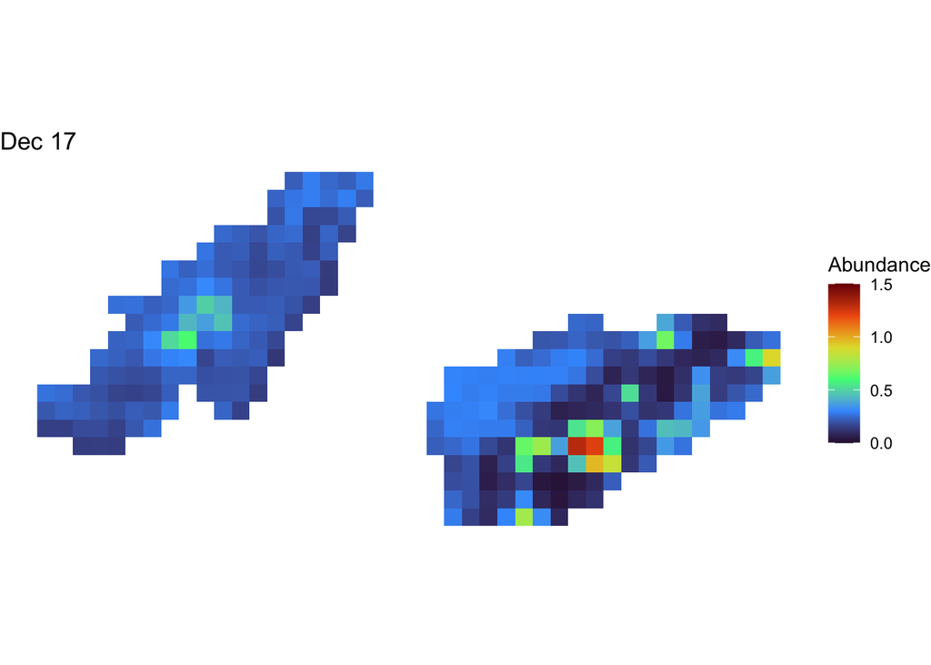

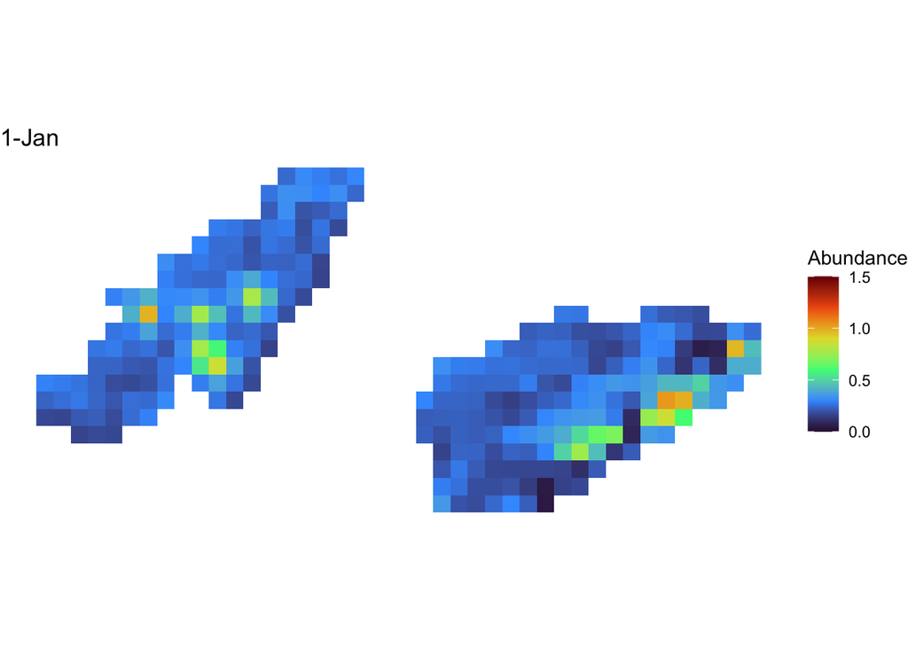

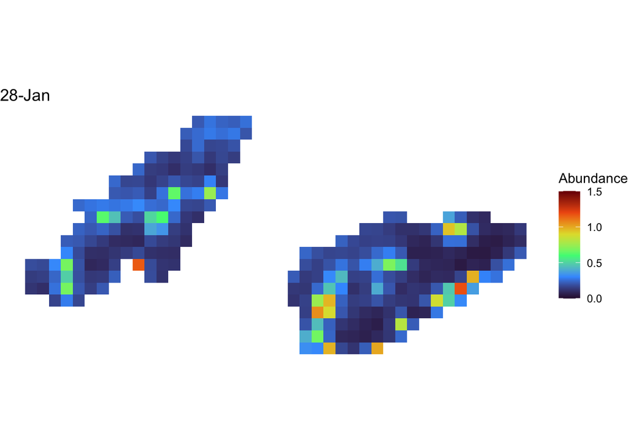

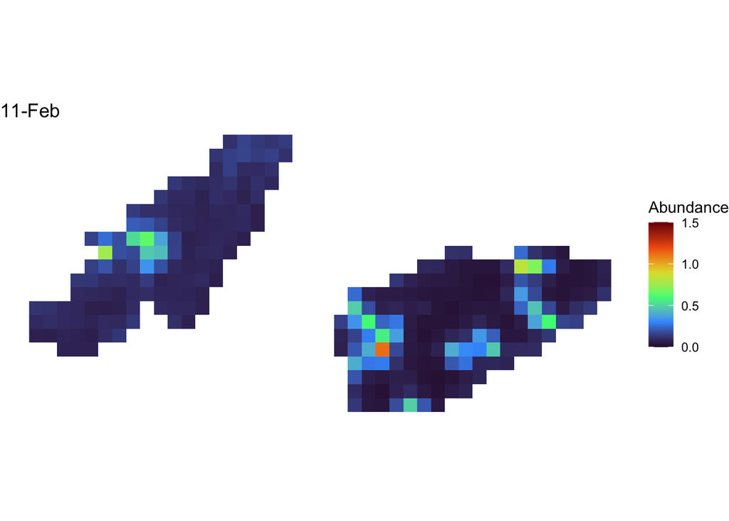

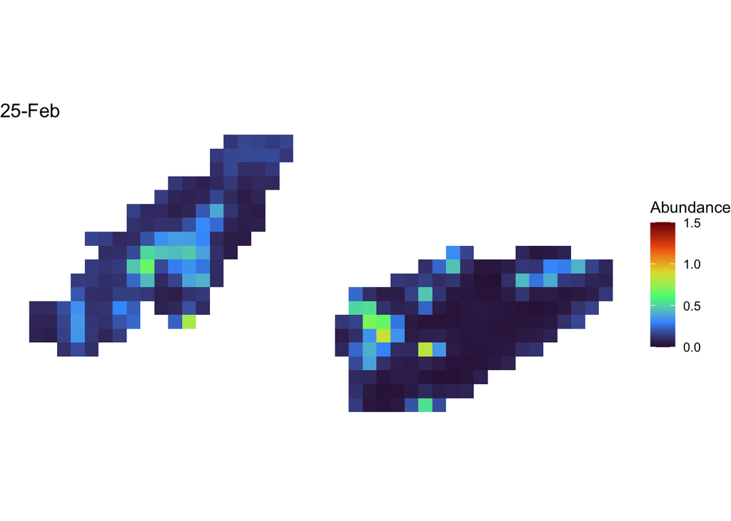

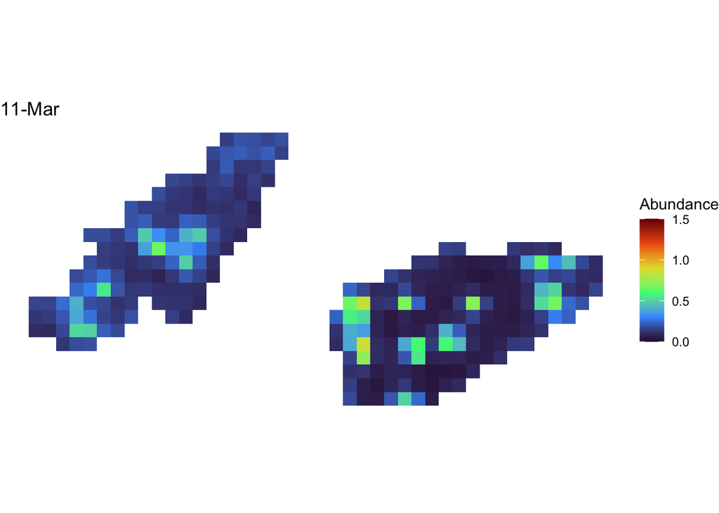

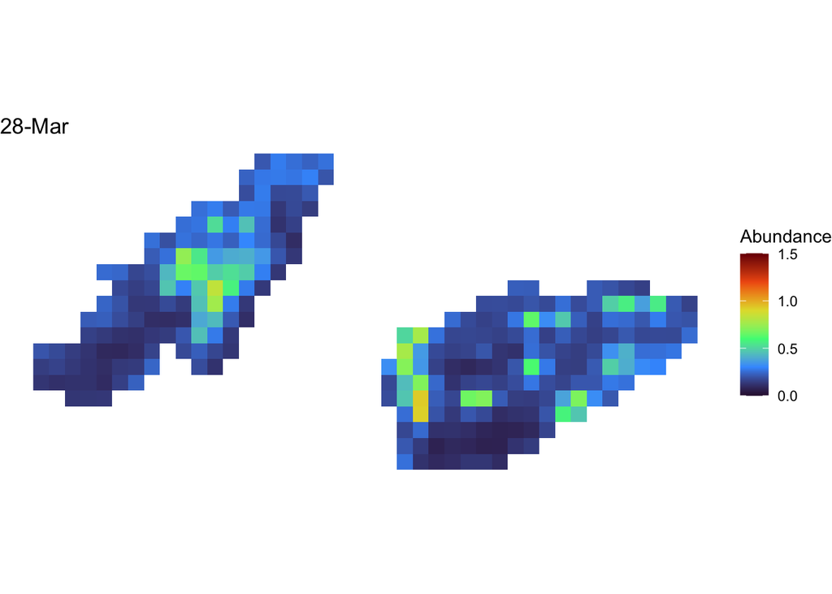

On average:

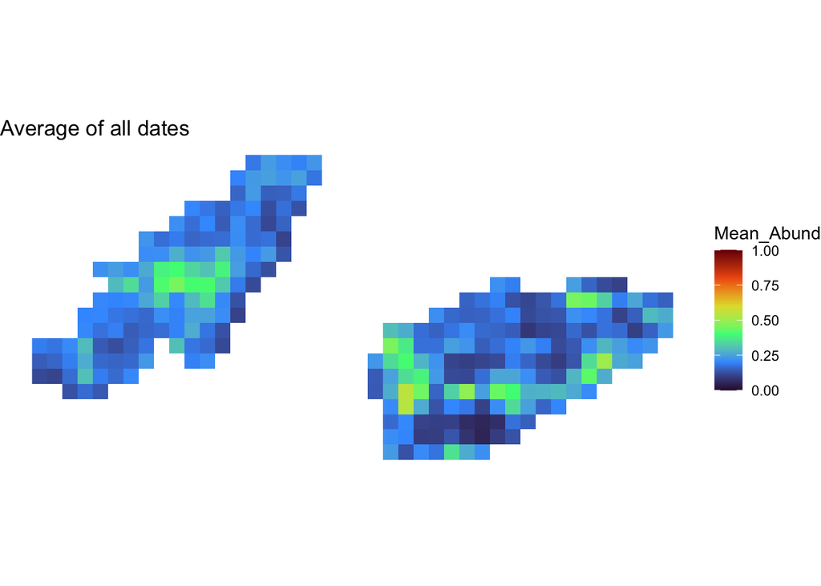

## Density by Habitat

Density of birds in each habitat type during each 2 week window.

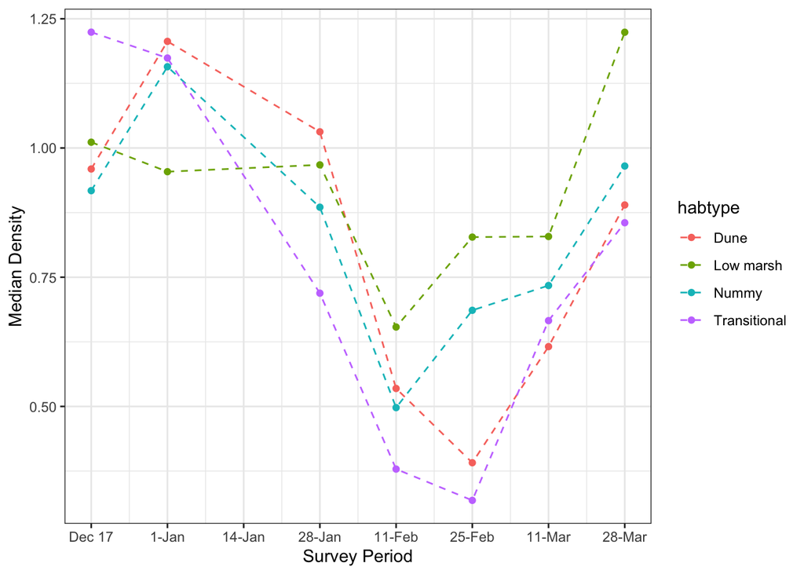

| habtype | Mean | LCI | UCI |
| --- | --- | --- | --- |
| Dune | 0.8040623 | 0.4126390 | 1.180046 |
| Low marsh | 0.9238305 | 0.6797276 | 1.192056 |
| Nummy | 0.8346995 | 0.5259446 | 1.128404 |
| Transitional | 0.7622529 | 0.3273434 | 1.216618 |

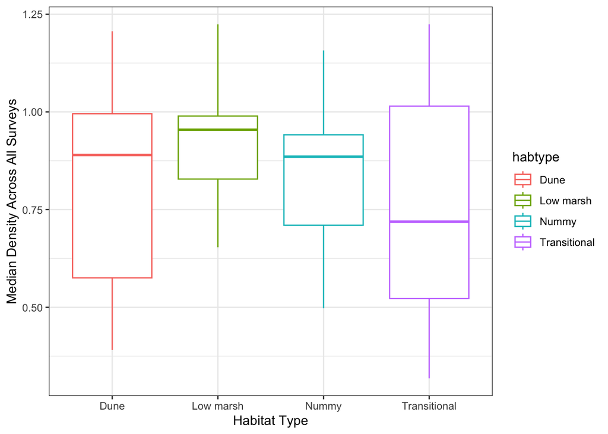

## Detection

Probability of detecting a sparrow assuming the activity center was directly on top of where we were standing to survey

```r
summary(nim.out[,c('lam0[1]', 'lam0[3]'),])$quantiles #Dune/Low/Transitional vs Nummy
```

```
##               2.5%       25%       50%       75%     97.5%
## lam0[1] 0.12688810 0.1711933 0.1985353 0.2290134 0.3050387
## lam0[3] 0.07285224 0.1061256 0.1262711 0.1483493 0.2013728
```

As our effort in each pixel increases, so does our detection. The graph shows the difference in detection for 2 m per 250m^2 pixel vs 200m of transect in a 250m^2 pixel.

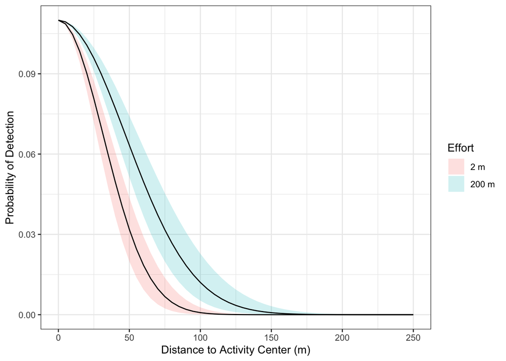

Side note: I thought we could maybe get pseudo home-range estimates out, but I don’t think we can because of the way we have to model set up. Oh well.

## Habitat Raster Used in Model

Values represent how much of the pixel is estimated to be water vs. vegetation. Higher values indicate less water and more ‘useable habitat.’

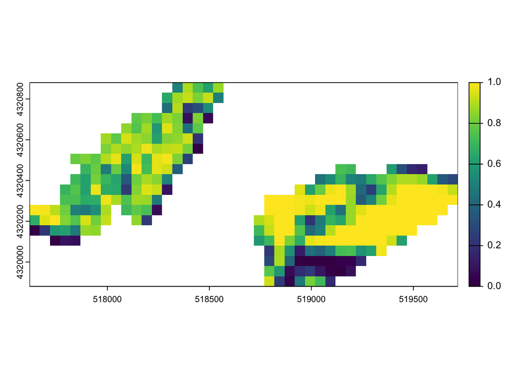

```r
plot(rast('notwater.tif'))
```